# Data Mining - HW 1

Thursday, January 15, 2015

authors: “Tzu-Yuan Lin, Marcus A. Streips”

**Question 1**

**(a) Read the data set. Our goal is to predict INCOME. How many records do we have?**

The data set has **32,561** records. Using the R `str` command gives us:

‘data.frame’: 32561 obs. of 11 variables:

**(b) What are the types of each field be (interval, ordinal, nominal, flag)?**

- AGE : int **(interval/continuous)**
- EMPLOYER: Factor w/ 9 levels " ?“,” Federal-gov“,..: **(nominal)**
- DEGREE : Factor w/ 16 levels " 10th“,” 11th“,..: **(ordinal)**
- MSTATUS : Factor w/ 7 levels " Divorced“,” Married-AF-spouse“,..: **(nominal)**
- JOBTYPE : Factor w/ 15 levels " ?“,” Adm-clerical“,..: **(nominal)**
- SEX : Factor w/ 2 levels " Female“,” Male“: . **(flag)**
- C.GAIN : int 2174 0 0 0 0 0 0 0 14084 5178 … **(interval/continuous)**
- C.LOSS : int 0 0 0 0 0 0 0 0 0 0 … **(interval/continuous)**
- HOURS : int 40 13 40 40 40 40 16 45 50 40 … **(interval/continuous)**
- COUNTRY : Factor w/ 42 levels " ?“,” Cambodia“,..: .**(nominal)**
- INCOME : Factor w/ 2 levels " <=50K“,” >50K“: **(flag)**

**(c) What effect does each of these three fields seem to have on INCOME?**

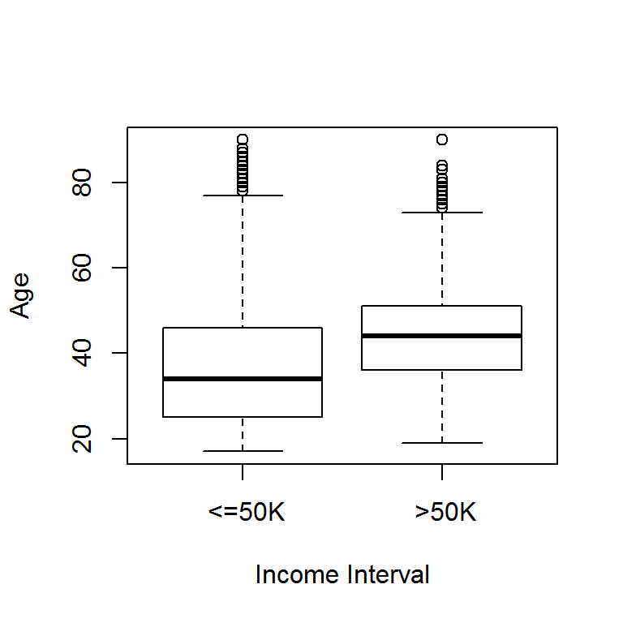

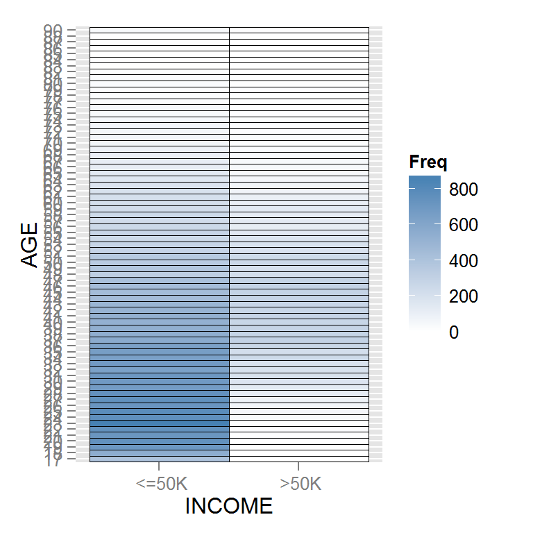

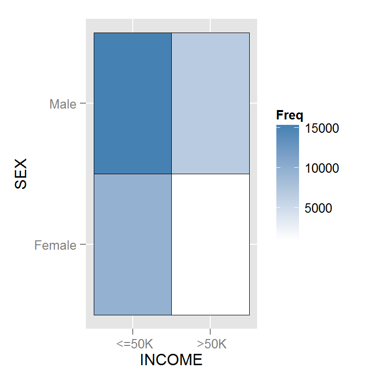

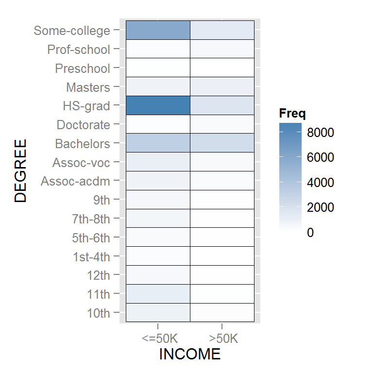

**Question 2**

**(a) Find the support and confidence for the rule “if department = systems then salary = 46K..50K”**

Using the `apriori` command from the `arules` package we get the following:

```r
   lhs                     rhs                      support confidence     lift

12 {department=systems} => {salary=46K..50K}      0.1388889  0.7142857 1.978022
```

**(b) Which of these three sets of rules has the lowest misclassification rate?**

Using the `C5.0` command from the `C50` package we determine that **AGE** has the lowest misclassification rate at **27.8%** (see results below), when compared to status (50%) and department (52.8%)(results not shown).

```r
Evaluation on training data (180 cases):

                Rules
      ----------------
        No      Errors

         5   50(27.8%)   <<


       (a)   (b)   (c)   (d)   (e)   (f)    <-classified as
      ----  ----  ----  ----  ----  ----
        50                                  (a): class 26K..30K
              40                            (b): class 31K..35K
                     5                      (c): class 36K..40K
              10                            (d): class 41K..45K
         5    30                30          (e): class 46K..50K
               5                       5    (f): class 66K..70K
```